# Fordgobike data visualization

Bay Wheels is a regional public bicycle sharing system in California's San Francisco Bay Area. It is operated by Motivate in a partnership with the Metropolitan Transportation Commission and the Bay Area Air Quality Management District.Bay Wheels is the first regional and large-scale bicycle sharing system deployed in California and on the West Coast of the United States. It was established as Bay Area Bike Share in August 2013. As of January 2018, the Bay Wheels system had over 2,600 bicycles in 262 stations across San Francisco, East Bay and San Jose. In June 2017 the system was officially re-launched as Ford GoBike in a partnership with Ford Motor Company. After Motivate's acquisition by Lyft, the system was renamed to Bay Wheels in June 2019. The system is expected to expand to 7,000 bicycles around 540 stations in San Francisco, Oakland, Berkeley, Emeryville, and San Jose.

Source: https://en.wikipedia.org/wiki/Bay_Wheels

```python
import pandas as pd
import numpy as np
import matplotlib.pyplot as plt
import statsmodels.api as sm
import requests
from pathlib import Path
from bs4 import BeautifulSoup
import seaborn as sb
from geopy import Point, distance
from geopy.distance import vincenty
import glob
import os
plt.rcParams['figure.figsize'] = [15, 7] # For bigger plots
plt.style.use('fivethirtyeight') # Special style template for matplotlib, highly useful for visualizing time series data
%matplotlib inline
```

## Gathering data

Data contains files from 2017-2019 year, and I used glob method to join them all together in one csv file.

```python
path = r'D:\data_analyst_nanodegree\project_5_data_visualization'
```

```python
all_files = glob.glob(os.path.join(path, "*.csv"))
```

```python
df = pd.concat((pd.read_csv(f) for f in all_files), ignore_index = True)
```

```python
df.to_csv('fordgobike.csv', index = False)
```

```python
bikes_df = pd.read_csv("fordgobike.csv")
```

```
c:\users\amina lejla\appdata\local\programs\python\python37\lib\site-packages\IPython\core\interactiveshell.py:3020: DtypeWarning: Columns (14,15) have mixed types.Specify dtype option on import or set low_memory=False.
  interactivity=interactivity, compiler=compiler, result=result)
```

## Assesing data

```python
bikes_df.head()
```

|  | duration_sec | start_time | end_time | start_station_id | start_station_name | start_station_latitude | start_station_longitude | end_station_id | end_station_name | end_station_latitude | end_station_longitude | bike_id | user_type | member_birth_year | member_gender | bike_share_for_all_trip |
| --- | --- | --- | --- | --- | --- | --- | --- | --- | --- | --- | --- | --- | --- | --- | --- | --- |
| 0 | 80110 | 2017-12-31 16:57:39.6540 | 2018-01-01 15:12:50.2450 | 74.0 | Laguna St at Hayes St | 37.776435 | -122.426244 | 43.0 | San Francisco Public Library (Grove St at Hyde... | 37.778768 | -122.415929 | 96 | Customer | 1987.0 | Male | NaN |
| 1 | 78800 | 2017-12-31 15:56:34.8420 | 2018-01-01 13:49:55.6170 | 284.0 | Yerba Buena Center for the Arts (Howard St at ... | 37.784872 | -122.400876 | 96.0 | Dolores St at 15th St | 37.766210 | -122.426614 | 88 | Customer | 1965.0 | Female | NaN |
| 2 | 45768 | 2017-12-31 22:45:48.4110 | 2018-01-01 11:28:36.8830 | 245.0 | Downtown Berkeley BART | 37.870348 | -122.267764 | 245.0 | Downtown Berkeley BART | 37.870348 | -122.267764 | 1094 | Customer | NaN | NaN | NaN |
| 3 | 62172 | 2017-12-31 17:31:10.6360 | 2018-01-01 10:47:23.5310 | 60.0 | 8th St at Ringold St | 37.774520 | -122.409449 | 5.0 | Powell St BART Station (Market St at 5th St) | 37.783899 | -122.408445 | 2831 | Customer | NaN | NaN | NaN |
| 4 | 43603 | 2017-12-31 14:23:14.0010 | 2018-01-01 02:29:57.5710 | 239.0 | Bancroft Way at Telegraph Ave | 37.868813 | -122.258764 | 247.0 | Fulton St at Bancroft Way | 37.867789 | -122.265896 | 3167 | Subscriber | 1997.0 | Female | NaN |

```python
bikes_df.shape
```

```
(3619900, 16)
```

```python
bikes_df.describe()
```

|  | duration_sec | start_station_id | start_station_latitude | start_station_longitude | end_station_id | end_station_latitude | end_station_longitude | bike_id | member_birth_year |
| --- | --- | --- | --- | --- | --- | --- | --- | --- | --- |
| count | 3.619900e+06 | 3.607187e+06 | 3.619900e+06 | 3.619900e+06 | 3.607187e+06 | 3.619900e+06 | 3.619900e+06 | 3.619900e+06 | 3.211306e+06 |
| mean | 8.626816e+02 | 1.228494e+02 | 3.776866e+01 | -1.223527e+02 | 1.210783e+02 | 3.776863e+01 | -1.223516e+02 | 2.778914e+03 | 1.983228e+03 |
| std | 2.410442e+03 | 1.044131e+02 | 1.032530e-01 | 1.568280e-01 | 1.043030e+02 | 1.316769e-01 | 3.078634e-01 | 1.749201e+03 | 1.042724e+01 |
| min | 6.100000e+01 | 3.000000e+00 | 0.000000e+00 | -1.224737e+02 | 3.000000e+00 | 0.000000e+00 | -1.224737e+02 | 1.000000e+01 | 1.878000e+03 |
| 25% | 3.500000e+02 | 3.400000e+01 | 3.777106e+01 | -1.224117e+02 | 3.000000e+01 | 3.777106e+01 | -1.224108e+02 | 1.362000e+03 | 1.978000e+03 |
| 50% | 5.550000e+02 | 8.900000e+01 | 3.778107e+01 | -1.223983e+02 | 8.800000e+01 | 3.778127e+01 | -1.223974e+02 | 2.626000e+03 | 1.986000e+03 |
| 75% | 8.690000e+02 | 1.930000e+02 | 3.779539e+01 | -1.222914e+02 | 1.910000e+02 | 3.779625e+01 | -1.222934e+02 | 3.929000e+03 | 1.991000e+03 |
| max | 8.636900e+04 | 4.270000e+02 | 4.551000e+01 | 0.000000e+00 | 4.270000e+02 | 4.551000e+01 | 0.000000e+00 | 7.196000e+03 | 2.001000e+03 |

```python
bikes_df.isna().sum()
```

```
duration_sec                    0
start_time                      0
end_time                        0
start_station_id            12713
start_station_name          12713
start_station_latitude          0
start_station_longitude         0
end_station_id              12713
end_station_name            12713
end_station_latitude            0
end_station_longitude           0
bike_id                         0
user_type                       0
member_birth_year          408594
member_gender              408161
bike_share_for_all_trip    519700
dtype: int64
```

As we can tell, a lot of data has NaN values, and we can work with that by inserting the average value (for birth year), or to just leave it as it is (for stations).

# Cleaning data

**Let's calculate the distance between starting point (starting latitude and longitude) and end point (end station latitude and longitude) in kilometers based on Haversine formula. We can use this data for further insights.**

```python
def Haversine(lat1,lon1,lat2,lon2, **kwarg):
    """
    This uses the ‘haversine’ formula to calculate the great-circle distance between two points – that is,
    the shortest distance over the earth’s surface – giving an ‘as-the-crow-flies’ distance between the points
    (ignoring any hills they fly over, of course!).
    Haversine
    formula:    a = sin²(Δφ/2) + cos φ1 ⋅ cos φ2 ⋅ sin²(Δλ/2)
    c = 2 ⋅ atan2( √a, √(1−a) )
    d = R ⋅ c
    where   φ is latitude, λ is longitude, R is earth’s radius (mean radius = 6,371km);
    note that angles need to be in radians to pass to trig functions!
    """
    R = 6371.0088
    lat1,lon1,lat2,lon2 = map(np.radians, [bikes_df['start_station_latitude'],
                                          bikes_df['start_station_longitude'],
                                           bikes_df['end_station_latitude'],
                                           bikes_df['end_station_longitude']])

    dlat = lat2 - lat1
    dlon = lon2 - lon1
    a = np.sin(dlat/2)**2 + np.cos(lat1) * np.cos(lat2) * np.sin(dlon/2) **2
    c = 2 * np.arctan2(a**0.5, (1-a)**0.5)
    d = R * c
    return round(d,4)
```

**Creating the new column for distance**

```python
bikes_df['distance[km]'] = Haversine(bikes_df['start_station_latitude'],
             bikes_df['start_station_longitude'],
             bikes_df['end_station_latitude'],
             bikes_df['end_station_longitude'])
bikes_df.head(5)
```

|  | duration_sec | start_time | end_time | start_station_id | start_station_name | start_station_latitude | start_station_longitude | end_station_id | end_station_name | end_station_latitude | end_station_longitude | bike_id | user_type | member_birth_year | member_gender | bike_share_for_all_trip | distance[km] |
| --- | --- | --- | --- | --- | --- | --- | --- | --- | --- | --- | --- | --- | --- | --- | --- | --- | --- |
| 0 | 80110 | 2017-12-31 16:57:39.6540 | 2018-01-01 15:12:50.2450 | 74.0 | Laguna St at Hayes St | 37.776435 | -122.426244 | 43.0 | San Francisco Public Library (Grove St at Hyde... | 37.778768 | -122.415929 | 96 | Customer | 1987.0 | Male | NaN | 0.9429 |
| 1 | 78800 | 2017-12-31 15:56:34.8420 | 2018-01-01 13:49:55.6170 | 284.0 | Yerba Buena Center for the Arts (Howard St at ... | 37.784872 | -122.400876 | 96.0 | Dolores St at 15th St | 37.766210 | -122.426614 | 88 | Customer | 1965.0 | Female | NaN | 3.0697 |
| 2 | 45768 | 2017-12-31 22:45:48.4110 | 2018-01-01 11:28:36.8830 | 245.0 | Downtown Berkeley BART | 37.870348 | -122.267764 | 245.0 | Downtown Berkeley BART | 37.870348 | -122.267764 | 1094 | Customer | NaN | NaN | NaN | 0.0000 |
| 3 | 62172 | 2017-12-31 17:31:10.6360 | 2018-01-01 10:47:23.5310 | 60.0 | 8th St at Ringold St | 37.774520 | -122.409449 | 5.0 | Powell St BART Station (Market St at 5th St) | 37.783899 | -122.408445 | 2831 | Customer | NaN | NaN | NaN | 1.0466 |
| 4 | 43603 | 2017-12-31 14:23:14.0010 | 2018-01-01 02:29:57.5710 | 239.0 | Bancroft Way at Telegraph Ave | 37.868813 | -122.258764 | 247.0 | Fulton St at Bancroft Way | 37.867789 | -122.265896 | 3167 | Subscriber | 1997.0 | Female | NaN | 0.6363 |

**Let's transform data type for time to datetime**

```python
bikes_df.start_time = pd.to_datetime(bikes_df.start_time)
bikes_df.end_time = pd.to_datetime(bikes_df.end_time)
```

**Let's calculate the age of members by deducting their birth year from year data is measured in**

```python
bikes_df['year'] = bikes_df['end_time'].dt.year
```

```python
bikes_df['member_age'] = bikes_df['year'] - bikes_df['member_birth_year']
```

```python
bikes_df['member_age'].max()
```

```
141.0
```

```python
bikes_df['member_age'].min()
```

```
18.0
```

```python
bikes_df['member_age'].mean()
```

```
34.94407633529785
```

```python
median = bikes_df.loc[bikes_df['member_age']<75, 'member_age'].median()
bikes_df['member_age'] = np.where(bikes_df['member_age'] > 75, median, bikes_df['member_age'])
bikes_df['member_age'] = bikes_df['member_age'].fillna(median)
```

```python
bikes_df['member_age'].sort_values()
```

```
1851271    18.0
1446590    18.0
2253448    18.0
1780759    18.0
2076577    18.0
           ...
2184391    75.0
2184448    75.0
2112361    75.0
2222968    75.0
912060     75.0
Name: member_age, Length: 3619900, dtype: float64
```

**Let's calculate trip duration in minutes because that is the most common unit for these trips**

```python
bikes_df['duration_min'] = (bikes_df['duration_sec'])/60
```

Wherever there is Nan value for gender, we will replace it with 'Other'

```python
bikes_df['member_gender'] = bikes_df['member_gender'].fillna('Other')
```

```python
bikes_df['start_station_id'].isna().sum()
```

```
12713
```

**Categorizing variables**

```python
bikes_df['member_gender'] = bikes_df['member_gender'].astype('category')
bikes_df['user_type'] = bikes_df['user_type'].astype('category')
bikes_df['bike_share_for_all_trip'] = bikes_df['bike_share_for_all_trip'].astype('category')
```

**Drop unnecessary columns**

Since we calculated the distance of trips and age of members, we can drop some of the columns

```python
bikes_df = bikes_df.drop(['start_station_latitude', 'start_station_longitude', 'end_station_latitude',
               'end_station_longitude', 'member_birth_year'], axis=1)
```

**Use integers where possible**

```python
bikes_df['member_age'] = bikes_df['member_age'].astype(int)
bikes_df['duration_min'] = bikes_df['duration_min'].astype(int)
```

**Extracting day and month from dates**

```python
bikes_df['month'] = bikes_df['start_time'].dt.strftime('%B')
```

```python
bikes_df['day'] = bikes_df['start_time'].dt.strftime('%A')
```

**In order to determine at what time are the bikes mostly used, we will split start time into hours, weekdays and months.**

```python
bikes_df['start_hour'] = bikes_df['start_time'].dt.hour
bikes_df['end_hour'] = bikes_df['end_time'].dt.hour
```

**Testing**

```python
bikes_df['member_gender'].value_counts()
```

```
Male      2381779
Female     776534
Other      461587
Name: member_gender, dtype: int64
```

**Discuss the distribution(s) of your variable(s) of interest. Were there any unusual points? Did you need to perform any transformations?**

The only unusal values (outliers) are some age numbers - maximum was 141 years old, but I replaced all the outliers with median value of age. Also, some trips last too long-but there are very few of them and they don't affect my analysis because I excluded them.

**Of the features you investigated, were there any unusual distributions? Did you perform any operations on the data to tidy, adjust, or change the form of the data? If so, why did you do this?**

### Univariate exploration

This is an investigation of distribution of one single variable at the time. This leads to better insight into data for further, more complex analysis of relations between different variables

Let's see how busy on average are months, days and different times of a day. This could be an useful insight into bikers' movements. First, we will plot the bar chart in the decreasing order of the frequency of the week day.

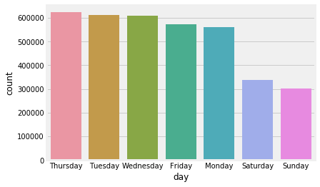

```python
freq = bikes_df['day'].value_counts()
gen_order = freq.index
sb.countplot(data=bikes_df, x='day', order=gen_order);
```

We can see that weekends are the least busy days-that was expected since many people aren't going to work and therefore not using bikes as much.

Next, we will plot the bar chart of the frequency of the starting hour - we can tell that morning and afternoon are the bussiest times - that's when people are going to and from work of course.

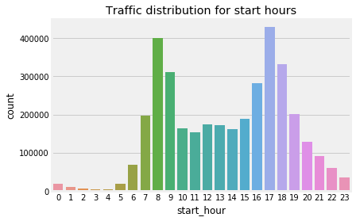

```python
freq = bikes_df['start_hour'].value_counts()
sb.countplot(data=bikes_df, x='start_hour')
plt.title("Traffic distribution for start hours");
```

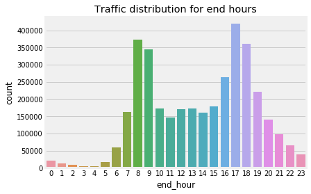

```python
freq = bikes_df['end_hour'].value_counts()
sb.countplot(data=bikes_df, x='end_hour')
plt.title("Traffic distribution for end hours");
```

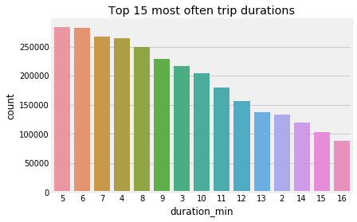

```python
freq = bikes_df['duration_min'].value_counts().head(15)
gen_order = freq.index
sb.countplot(data=bikes_df, x='duration_min', order=gen_order)
plt.title("Top 15 most often trip durations");
```

Let's see about the age of users. Most of them are in thirties, as expected. Number 33 has especially large count, since we replaced the missing values with median value of age which was 33.

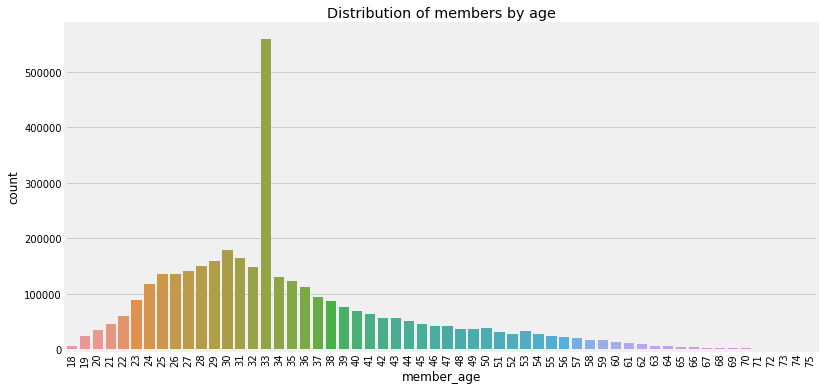

```python
freq = bikes_df['member_age'].value_counts().head(15)
plt.figure(figsize=(12,6))
age = sb.countplot(data=bikes_df, x='member_age')
age.set_xticklabels(age.get_xticklabels(), rotation=90)
plt.title("Distribution of members by age");
```

Let's see which are the most popular stations. We can use this for business opportunities-to put more bikes or advertisement on those stations.

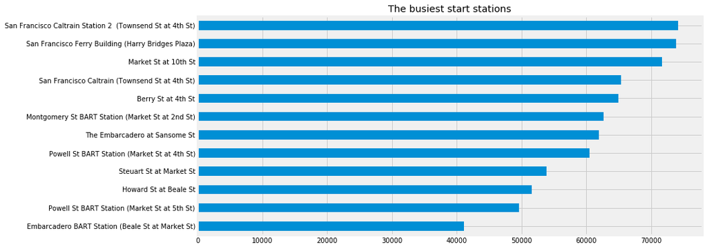

```python
bikes_df['start_station_name'].value_counts()[11::-1].plot(kind='barh', figsize=(12,6))
plt.title("The busiest start stations");
```

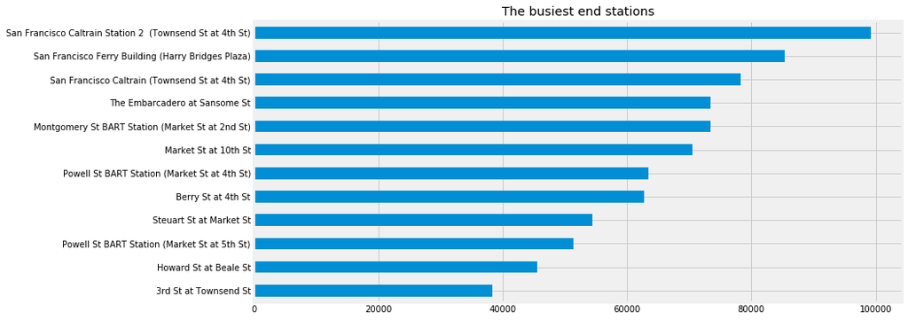

```python
bikes_df['end_station_name'].value_counts()[11::-1].plot(kind='barh', figsize=(12,6))
plt.title("The busiest end stations");
```

As expected, stations are repeating as start and end stations. This is probably industrial and/or business area.

```python
bikes_df.sample(4)
```

|  | duration_sec | start_time | end_time | start_station_id | start_station_name | end_station_id | end_station_name | bike_id | user_type | member_gender | bike_share_for_all_trip | distance[km] | year | member_age | duration_min | month | day | start_hour | end_hour |
| --- | --- | --- | --- | --- | --- | --- | --- | --- | --- | --- | --- | --- | --- | --- | --- | --- | --- | --- | --- |
| 317036 | 1257 | 2017-09-23 12:19:22.086 | 2017-09-23 12:40:19.522 | 4.0 | Cyril Magnin St at Ellis St | 76.0 | McCoppin St at Valencia St | 2985 | Customer | Female | NaN | 1.9771 | 2017 | 34 | 20 | September | Saturday | 12 | 12 |
| 3595818 | 388 | 2019-02-05 18:06:01.360 | 2019-02-05 18:12:29.684 | 195.0 | Bay Pl at Vernon St | 183.0 | Telegraph Ave at 19th St | 4704 | Subscriber | Male | No | 0.8985 | 2019 | 43 | 6 | February | Tuesday | 18 | 18 |
| 1432385 | 335 | 2018-07-17 21:48:53.297 | 2018-07-17 21:54:28.929 | 47.0 | 4th St at Harrison St | 26.0 | 1st St at Folsom St | 3960 | Subscriber | Female | No | 0.8479 | 2018 | 21 | 5 | July | Tuesday | 21 | 21 |
| 1214442 | 614 | 2018-06-20 15:12:10.827 | 2018-06-20 15:22:25.510 | 112.0 | Harrison St at 17th St | 127.0 | Valencia St at 21st St | 254 | Subscriber | Male | No | 1.0618 | 2018 | 29 | 10 | June | Wednesday | 15 | 15 |

### Bivariate exploration

We are investigate relationships between variables in the data and discovering some potential business ideas.

Let's check the ratio of customers vs.subscribers.

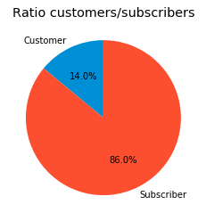

```python
plt.pie(
    bikes_df.groupby('user_type')['bike_id'].sum()/bikes_df['bike_id'].sum(),
    labels = sorted(bikes_df['user_type'].unique()),
    startangle=90,
    autopct='%1.1f%%'
);
plt.title("Ratio customers/subscribers");
```

As expected, subscribers are present in much larger number. We need to have some insight in their behaviour because they are target group, but we also need to find a way how to transform customers into subscribers.

Let's see male to female ratio. Remember, we filled the missing values with 'Other'.

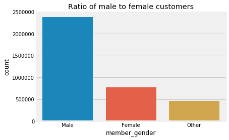

```python
freq = bikes_df['member_gender'].value_counts().head(15)
gen_order = freq.index
sb.countplot(data=bikes_df, x='member_gender', order=gen_order)
plt.title("Ratio of male to female customers");
```

Many more men than women are using bikes.

Let's see the distribution of duration of trips by year.

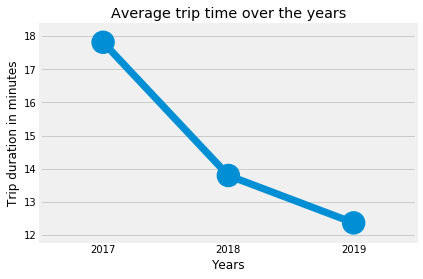

```python
ax = sb.pointplot(data=bikes_df, x='year' , y='duration_min')
plt.xlabel('Years')
plt.ylabel('Trip duration in minutes')
plt.title('Average trip time over the years');
```

Seems like people are taking bikes on shorter trips each year, od maybe a shortcut between the busiest stations was built meanwhile.

This is the distribution of the duration of trip by users.

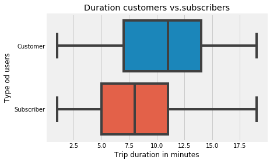

```python
sb.boxplot(data =bikes_df[bikes_df['duration_min'] < 20], y='user_type', x='duration_min')
plt.title('Duration customers vs.subscribers')
plt.xlabel('Trip duration in minutes')
plt.ylabel('Type od users');
```

Seems like the average trip of subscribers is shorter than customer trip. This is understandable, since subscribers most likely already have their everyday route whereas customers are more likely to take bikes and explore around.

Let's see the difference in behavior between customers and subscribers on a weekly basis. Especially interesting is weekend time.

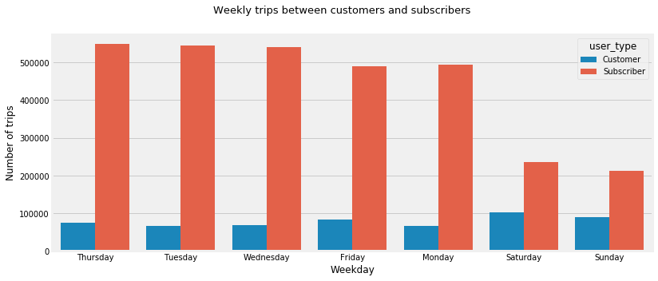

```python
plt.figure(figsize = [12, 5])
sb.countplot(data=bikes_df, x='day', hue='user_type', order=bikes_df['day'].value_counts().index)
plt.xlabel('Weekday')
plt.ylabel('Number of trips');
plt.suptitle('Weekly trips between customers and subscribers', fontsize=13);
```

As expected, customers are more active on weekends than on working days, whereas subscribers are using bikes less on weekends.

**Talk about some of the relationships you observed in this part of the investigation. How did the feature(s) of interest vary with other features in the dataset?**

The difference between customers and subscribers is obvious- customers are probably tourists who rent bikes mainly on weekends and more often in the evening hours. Subscribers are day to day work commuters or students who use bikes during weekdays, and for shorter distances.

**Did you observe any interesting relationships between the other features (not the main feature(s) of interest)?**

There is a difference between gender number-many more man than women. Also, there is a difference in trip duration between customers and subscribers (customers take longer trips), as well as decrease in average trip duration over the years - which tells us that number of subscribers has increased and maybe some new roads have been introduces as shortcuts.

### Multivariate exploration

Further exploration of the data by creating plots of three or more variables.

Let's see what is the ratio of subscribers vs.customers between the two genders

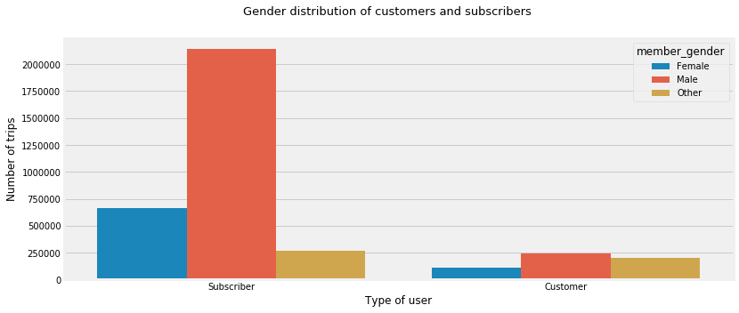

```python
plt.figure(figsize = [12, 5])
sb.countplot(data=bikes_df, x='user_type', hue='member_gender', order=bikes_df['user_type'].value_counts().index)
plt.xlabel('Type of user')
plt.ylabel('Number of trips');
plt.suptitle('Gender distribution of customers and subscribers', fontsize=13);
```

As expected, the distribution of genders per day is following the same trend.

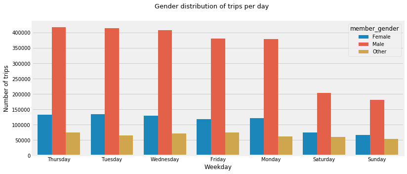

```python
plt.figure(figsize = [12, 5])
sb.countplot(data=bikes_df, x='day', hue='member_gender', order=bikes_df['day'].value_counts().index)
plt.xlabel('Weekday')
plt.ylabel('Number of trips');
plt.suptitle('Gender distribution of trips per day', fontsize=13);
```

Most of the trips are done by male subscribers. Also, we can notice that more 'Other' genders are present in customers. That is probably due to the fact that one or few time users (customers) don't want to enter their full data (gender is one of those options too).

As expected, subscribers' number decreases on weekends, whereas customers number increases.

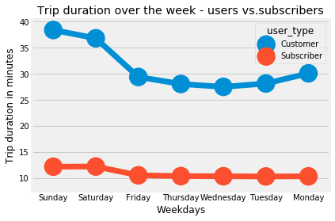

```python
sb.pointplot(data=bikes_df, x='day' , y='duration_min', hue='user_type')
plt.xlabel('Weekdays')
plt.ylabel('Trip duration in minutes')
plt.title('Trip duration over the week - users vs.subscribers');
```

Customers have longer average trips than subscribers during the week.

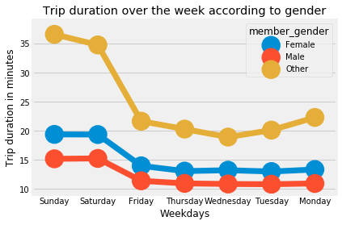

```python
sb.pointplot(data=bikes_df, x='day' , y='duration_min', hue='member_gender')
plt.xlabel('Weekdays')
plt.ylabel('Trip duration in minutes')
plt.title('Trip duration over the week according to gender');
```

Interesting observation is that females trip lasts longer on average than male, but it is following the same trend on weekdays. It is longer on the weekends and shorter during workdays. Category 'Other' has the longest average trips-those are probably one-time users such as tourists that refused to fill in their complete information.

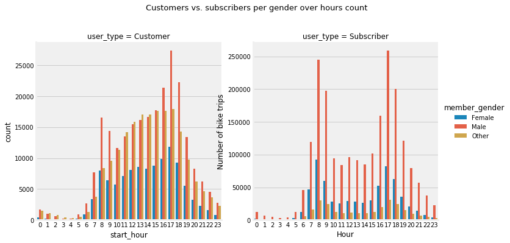

```python
sb.catplot(data=bikes_df,x='start_hour', col='user_type', hue='member_gender', sharey=False, kind='count')
plt.xlabel('Hour')
plt.ylabel('Number of bike trips')
plt.suptitle('Customers vs. subscribers per gender over hours count', fontsize=13, y=1.1);
```

It is obvious that customers are more active during the day, whereas subscribers are most active in the mornings and in the afternoon - that's the time of going and coming back from work.

Let's observe behaviour of customers and subscribers during the weekdays.

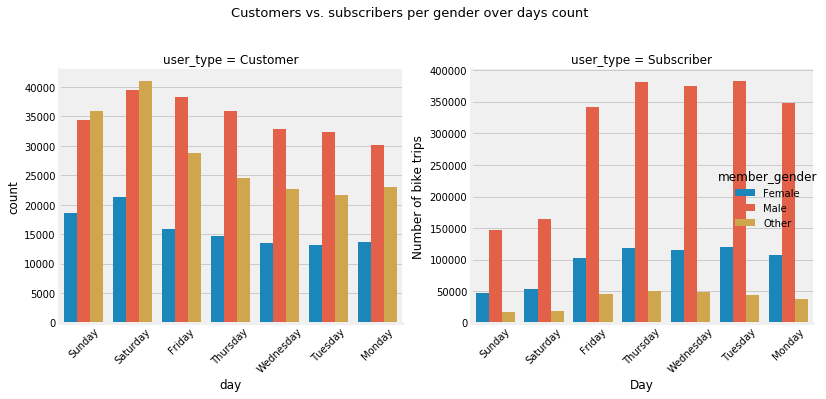

```python
day = sb.catplot(data=bikes_df, x='day', col='user_type', hue='member_gender', sharey=False, kind='count')
plt.xlabel('Day')
day.set_xticklabels(rotation=45)
plt.ylabel('Number of bike trips')
plt.suptitle('Customers vs. subscribers per gender over days count', fontsize=13, y=1.1)
plt.xticks(rotation = 45)
plt.tight_layout();
```

Let's see at which hours are customers and subscribers the most active for each day.

[figure not shown]

```python
customer_df = bikes_df.query('user_type == "Customer"').groupby(["start_hour", "day"])["bike_id"].size().reset_index()
customer_df = customer_df.pivot('start_hour','day','bike_id')
sb.heatmap(df_customer,cmap='YlGnBu')
plt.title("Customer", y=1.1, fontsize=12)
plt.xlabel('Weekday')
plt.ylabel('Start hour');
```

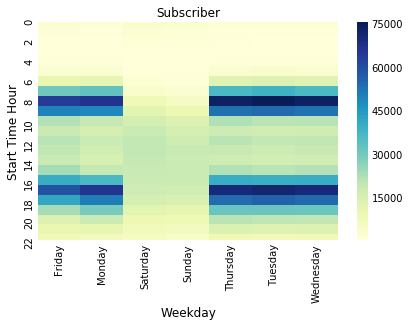

```python
subscriber_df = bikes_df.query('user_type == "Subscriber"').groupby(["start_hour", "day"])["bike_id"].size().reset_index()
subscriber_df = subscriber_df.pivot('start_hour','day','bike_id')
sb.heatmap(subscriber_df, cmap='YlGnBu')
plt.title("Subscriber", y=1.1, fontsize=12)
plt.xlabel('Weekday')
plt.ylabel('Start hour');
```

**Talk about some of the relationships you observed in this part of the investigation. Were there features that strengthened each other in terms of looking at your feature(s) of interest?**

**Were there any interesting or surprising interactions between features?**

Females take longer trips than males. Others take the longest trips, probably because those are one time users or it is their first use of the system, and they choose not to identify themselves.